# Predicting Weight-Lifting Quality

Aaron Ferrucci

October 17, 2015

## Overview

Accelometer devices make it possible to collect data from subjects performing weight-lifting exercises. It’s possible that user technique during such exercises may be significant - indicating risk of injury, or low rate of improvement. Quantifying the *quality* of exercise; whether in real time, or in post-processing could be a valuable training aid.

This project takes as input a set of data gathered during weight-lifting exercises, and attempts to discern, via machine learning classification modeling, whether the exercises were done correctly or incorrectly.

If a reasonable predictive model can be built, it could be implemented as a fitness product on a mobile device. Because mobile devices are typically underpowered in terms of compute performances, finding a model with lower compute requirements is desirable.

## Preliminaries

The test and training data sets are provided as files in .csv format. First, I’ll load in the training data set and do some basic exploratory analysis.

```r
train_all <- read.csv("pml-training.csv")
```

The data set consists of 19622 observations of 160 variables. As explained in (Ugulino, W.; Cardador, D.; Vega, K.; Velloso, E.; Milidiu, R.; Fuks, H.), the observations are of 6 individuals performing a weight-lifting exercise correctly, and then incorrectly in a number of ways. Correctness or not is encoded in the `classe` variable of the dataset, which is a factor variable of 5 levels, with the following interpretation:

- A: exactly according to the specification
- B: throwing the elbows to the front
- C: lifting the dumbbell only halfway
- D: lowering the dumbbell only halfway
- E: throwing the hips to the front

A contingency table by subject and class shows how many of each type of measurement were made, for each individual:

```r
table(train_all$classe, train_all$user_name)
```

```
##
##     adelmo carlitos charles eurico jeremy pedro
##   A   1165      834     899    865   1177   640
##   B    776      690     745    592    489   505
##   C    750      493     539    489    652   499
##   D    515      486     642    582    522   469
##   E    686      609     711    542    562   497
```

## Reducing Covariates

To improve scalability of any classification algorithm, it’s worth trying to reduce the data size to only those measurements which matter.

The dataset contains a large number measurements which are NA or empty string (“”):

```r
nas <- apply(train_all, 2, function(x) sum(ifelse(is.na(x), 1, 1 * (x == ""))))
t <- table(nas)
t
```

```
## nas
##     0 19216
##    60   100
```

When a measurement contains any missing values, it contains a large number of them (19216 out of 19622 total measurements). Looking closer, I see that variables which have mostly missing values have actual values when the variable new_window is “yes”. The names of those variables indicate that they are summary statistics (min, max, avg, etc.) - in other words, they are transformed tidy or Level 2 covariates. In the interest of letting the machine learning algorithm discover the necessary variables, I will discard all these transformed covariates.

```r
train_all <- train_all[, nas == 0]
```

Next, I’ll find and eliminate any covariates which have little impact on the outcome (via `nearZeroVar`):

```r
nzv <- nearZeroVar(train_all, saveMetrics=T)
train_all <- train_all[,!nzv$nzv]
```

Finally, I’ll manually discard a few covariates based on “common sense”. For example, the `X` value is a simple index over all of the data; there are also a few timestamp values that are unlikely to be predictors for correct vs. incorrect weightlifting technique.

```r
train_all <- train_all[, -grep("timestamp|X|num_window", names(train_all))]
```

I’ve reduced the number of covariates to 54, which is a big improvement over the original data size.

## Preparing for Cross-Validation

I will separate the training set into train and validation subsets, and use the validation subset error as my out-of-sample error estimate. A good rule of thumb is to separate a data set into 60% training, 20% validation and 20% test. In this case, the test data has already been separated out. By the rule of thumb, the training and validation data are in a 3:1 ratio, so I’ll maintain that for my training and valaidation data with `p=0.75`.

```r
dp <- createDataPartition(y=train_all$classe, p=0.75, list=F)
train <- train_all[dp,]
validate <- train_all[-dp,]
```

## Random Forest - Initial Model

Using the separated training data, I’ll train a random forest, using all the default options. Despite the rumors, creation of the model takes only a few minutes, even on my ancient laptop. However, an attempt to build the same model with caret’s `train` function took much longer - so I avoided that.

```r
rf <- randomForest(classe ~ ., data=train)
rf
```

```
##
## Call:
##  randomForest(formula = classe ~ ., data = train)
##                Type of random forest: classification
##                      Number of trees: 500
## No. of variables tried at each split: 7
##
##         OOB estimate of  error rate: 0.49%
## Confusion matrix:
##      A    B    C    D    E  class.error
## A 4182    2    0    0    1 0.0007168459
## B    9 2834    5    0    0 0.0049157303
## C    0   16 2549    2    0 0.0070120764
## D    0    0   23 2387    2 0.0103648425
## E    0    0    2   10 2694 0.0044345898
```

### Examining the Initial Model: Estimate Out-of-Sample Error

### OOB error

One of the figures of merit reported for the random forest model is the OOB estimate. In theory, this estimate is an accurate estimate of the out-of-sample error. For this model, the OOB estimate was very low, indicating a good fit without danger of overfitting.

### Out-of-Sample error: Home brew

As a cross-check, I’ll implement my own out-of-sample estimate, using the reserved validation data. The concept here is that since I don’t have access to the test data, I’ll estimate the error on the test set using training data which was separated out before building the model.

How does the model perform on the validation data?

```r
modelError <- function(fit, data) {
  missClass <- sum(predict(fit, data) == data$classe)
  err <- missClass / nrow(data)
  return(100 - err * 100)
}

me <- modelError(rf, validate)
me
```

```
## [1] 0.3874388
```

The out-of-sample error estimate is not dissimilar to the random forest’s OOB estimate.

### Examining the Initial Model: Error vs. Number of Trees

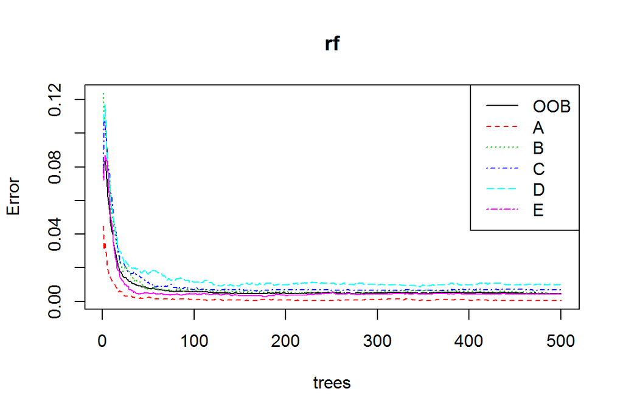

```r
plot(rf)
legend("topright", legend=colnames(rf$err.rate), lty=seq(ncol(rf$err.rate)), col=seq(ncol(rf$err.rate)))
```

After only 50 trees or so, the error rate has settled nicely. `randomForest()`’s default number of trees (500) is probably overkill.

### Examining the Initial Model: Variable Importance

Now that the model is trained, it’s interesting to have a look at variable importance. Since the model appears to be very accurate, could we trim this model, for better scalability, without sacrificing too much accuracy?

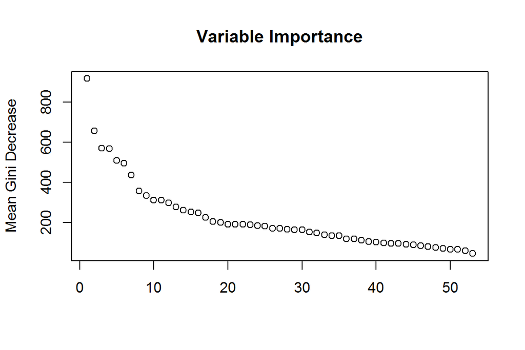

```r
order <- order(-rf$importance)
plot(
  rf$importance[order],
  main="Variable Importance",
  ylab = "Mean Gini Decrease",
  xlab=""
)
```

## Random Forest - Minimized Model

I’ll try training a new “minimized” random forest, using only the top 15 variables, and using only 100 trees.

```r
impNames <- rownames(rf$importance)[order]
minimal <- c(impNames[1:15], "classe")
dp_minimal <- createDataPartition(y=train_all$classe, p=0.75, list=F)
train_minimal <- train_all[dp_minimal,minimal]
validate_minimal <- train_all[-dp_minimal,minimal]
rf_minimal <- randomForest(classe ~ ., data=train_minimal, ntree=100)
rf_minimal
```

```
##
## Call:
##  randomForest(formula = classe ~ ., data = train_minimal, ntree = 100)
##                Type of random forest: classification
##                      Number of trees: 100
## No. of variables tried at each split: 3
##
##         OOB estimate of  error rate: 1.39%
## Confusion matrix:
##      A    B    C    D    E class.error
## A 4161   10    6    6    2 0.005734767
## B   24 2764   46   14    0 0.029494382
## C    0   28 2527   12    0 0.015582392
## D    0    1   25 2383    3 0.012023217
## E    1   10    7    9 2679 0.009977827
```

### Minimized Model: Out-of-Sample Error Estimate

```r
me_minimal <- modelError(rf_minimal, validate_minimal)
me_minimal
```

```
## [1] 1.019576
```

Once again, a similar figure is reported for the out-of-sample error estimate.

### Minimized Model: Error vs. Number of Trees

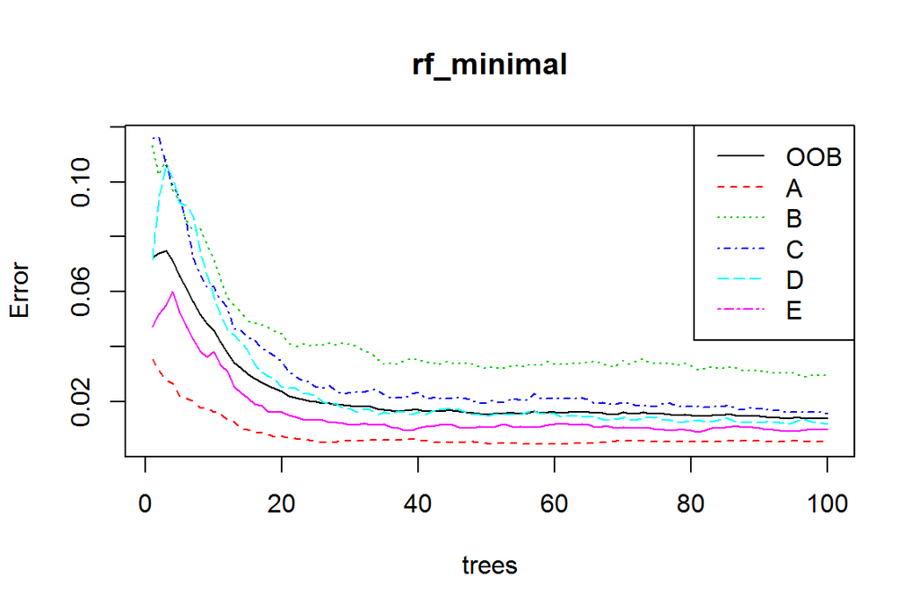

```r
plot(rf_minimal)
legend("topright", legend=colnames(rf_minimal$err.rate), lty=seq(ncol(rf_minimal$err.rate)),
col=seq(ncol(rf_minimal$err.rate)))
```

Again, after 50 trees or so, the error rate has settled nicely. So this “minimal” model should predict with reasonable accuracy.

## Model Final Test

As a final test, I’ll compare results between the initial and the minimal models, on the test data. This will be a relative test, comparing the results of the two models. I won’t feed back any info garnered here back into the models; therefore I think this is an allowed use of test data.

```r
test <- read.csv("pml-testing.csv")
answers <- predict(rf, test)
answers_minimal <- predict(rf_minimal, test)
all(answers == answers_minimal)
```

```
## [1] TRUE
```

The initial and the minimized model predict the same results on the test data set, so at the least, it appears that the minimal model could provide reasonable results with better scalability.

## Conclusions

- A complex and a simple random forest model were built; both achieved reasonable OOB estimates
- Out-of-sample estimates were calculated using cross-validation; the results were similar to the OOB estimates.
- The models predicted identical results on the reserved test data set.
- The minimal model may be suited to implementation on a low-powered mobile device - further profiling and optimization are required.

References

Ugulino, W.; Cardador, D.; Vega, K.; Velloso, E.; Milidiu, R.; Fuks, H. “Wearable Computing: Accelerometers’ Data Classification of Body Postures and Movements.” *Proceedings of 21st Brazilian Symposium on Artificial Intelligence*. http://groupware.les.inf.puc-rio.br/har.